# COVID-19 Vaccinations Progress

**Purpose**  
To view vaccine doses overview by country and by vaccine types. Throughout this project, I will look into how many countries are participating vaccinations daily and by each country's population.

**Emergency Use Authorization (EAU) Dates:**

- Pfizer – BioNTech: December 11, 2020
- Moderna: December 18, 2020
- Janssen: February 27, 2021

  *For more information, [FDA](https://www.fda.gov/emergency-preparedness-and-response/coronavirus-disease-2019-covid-19/covid-19-vaccines)*

Data can be found here: [Kaggle](https://www.kaggle.com/gpreda/covid-world-vaccination-progress)

**Key Performance Indicators:**

- Number of countries participating vaccination
- Daily counts per country
- 10 most vaccinated countries per population
- Types of vaccines have been used
- Day of week the most people get vaccinated in United States

```python
import numpy as np
import pandas as pd
```

```python
import matplotlib.pyplot as plt
%matplotlib inline
import chart_studio.plotly as py
import plotly.graph_objects as go
from plotly import __version__
from plotly.offline import download_plotlyjs, init_notebook_mode, plot, iplot
print(__version__)
import seaborn as sns
import cufflinks as cf

init_notebook_mode(connected = True)
```

```
4.14.3
```

```python
cf.go_offline()
```

```python
vaccine = pd.read_csv('country_vaccinations_030921.csv')
```

```python
vaccine.head()
```

|  | country | iso_code | date | total_vaccinations | people_vaccinated | people_fully_vaccinated | daily_vaccinations_raw | daily_vaccinations | total_vaccinations_per_hundred | people_vaccinated_per_hundred | people_fully_vaccinated_per_hundred | daily_vaccinations_per_million | vaccines | source_name | source_website |
| --- | --- | --- | --- | --- | --- | --- | --- | --- | --- | --- | --- | --- | --- | --- | --- |
| 0 | Albania | ALB | 2021-01-10 | 0.0 | 0.0 | NaN | NaN | NaN | 0.00 | 0.00 | NaN | NaN | Pfizer/BioNTech | Ministry of Health | https://shendetesia.gov.al/covid19-ministria-e... |
| 1 | Albania | ALB | 2021-01-11 | NaN | NaN | NaN | NaN | 64.0 | NaN | NaN | NaN | 22.0 | Pfizer/BioNTech | Ministry of Health | https://shendetesia.gov.al/covid19-ministria-e... |
| 2 | Albania | ALB | 2021-01-12 | 128.0 | 128.0 | NaN | NaN | 64.0 | 0.00 | 0.00 | NaN | 22.0 | Pfizer/BioNTech | Ministry of Health | https://shendetesia.gov.al/covid19-ministria-e... |
| 3 | Albania | ALB | 2021-01-13 | 188.0 | 188.0 | NaN | 60.0 | 63.0 | 0.01 | 0.01 | NaN | 22.0 | Pfizer/BioNTech | Ministry of Health | https://shendetesia.gov.al/covid19-ministria-e... |
| 4 | Albania | ALB | 2021-01-14 | 266.0 | 266.0 | NaN | 78.0 | 66.0 | 0.01 | 0.01 | NaN | 23.0 | Pfizer/BioNTech | Ministry of Health | https://shendetesia.gov.al/covid19-ministria-e... |

```python
vaccine.info()
```

```
<class 'pandas.core.frame.DataFrame'>
RangeIndex: 5457 entries, 0 to 5456
Data columns (total 15 columns):
 #   Column                               Non-Null Count  Dtype
---  ------                               --------------  -----
 0   country                              5457 non-null   object
 1   iso_code                             5121 non-null   object
 2   date                                 5457 non-null   object
 3   total_vaccinations                   3445 non-null   float64
 4   people_vaccinated                    3046 non-null   float64
 5   people_fully_vaccinated              2075 non-null   float64
 6   daily_vaccinations_raw               2890 non-null   float64
 7   daily_vaccinations                   5269 non-null   float64
 8   total_vaccinations_per_hundred       3445 non-null   float64
 9   people_vaccinated_per_hundred        3046 non-null   float64
 10  people_fully_vaccinated_per_hundred  2075 non-null   float64
 11  daily_vaccinations_per_million       5269 non-null   float64
 12  vaccines                             5457 non-null   object
 13  source_name                          5457 non-null   object
 14  source_website                       5457 non-null   object
dtypes: float64(9), object(6)
memory usage: 639.6+ KB
```

```python
vaccine['country'].nunique()    #number of countries
```

```
129
```

```python
vaccine['country'].unique()
```

```
array(['Albania', 'Algeria', 'Andorra', 'Anguilla', 'Argentina',
       'Australia', 'Austria', 'Azerbaijan', 'Bahrain', 'Bangladesh',
       'Barbados', 'Belarus', 'Belgium', 'Belize', 'Bermuda', 'Bolivia',
       'Brazil', 'Bulgaria', 'Cambodia', 'Canada', 'Cayman Islands',
       'Chile', 'China', 'Colombia', 'Costa Rica', 'Croatia', 'Cyprus',
       'Czechia', 'Denmark', 'Dominica', 'Dominican Republic', 'Ecuador',
       'Egypt', 'El Salvador', 'England', 'Estonia', 'Faeroe Islands',
       'Falkland Islands', 'Finland', 'France', 'Germany', 'Gibraltar',
       'Greece', 'Greenland', 'Grenada', 'Guatemala', 'Guernsey',
       'Guyana', 'Honduras', 'Hong Kong', 'Hungary', 'Iceland', 'India',
       'Indonesia', 'Iran', 'Ireland', 'Isle of Man', 'Israel', 'Italy',
       'Japan', 'Jersey', 'Jordan', 'Kazakhstan', 'Kuwait', 'Latvia',
       'Lebanon', 'Liechtenstein', 'Lithuania', 'Luxembourg', 'Macao',
       'Malaysia', 'Maldives', 'Malta', 'Mauritius', 'Mexico', 'Moldova',
       'Monaco', 'Mongolia', 'Montenegro', 'Montserrat', 'Morocco',
       'Myanmar', 'Nepal', 'Netherlands', 'New Zealand',
       'Northern Cyprus', 'Northern Ireland', 'Norway', 'Oman',
       'Pakistan', 'Panama', 'Paraguay', 'Peru', 'Philippines', 'Poland',
       'Portugal', 'Qatar', 'Romania', 'Russia', 'Rwanda', 'Saint Helena',
       'Saint Lucia', 'San Marino', 'Saudi Arabia', 'Scotland', 'Senegal',
       'Serbia', 'Seychelles', 'Singapore', 'Slovakia', 'Slovenia',
       'South Africa', 'South Korea', 'Spain', 'Sri Lanka', 'Sweden',
       'Switzerland', 'Thailand', 'Trinidad and Tobago', 'Turkey',
       'Turks and Caicos Islands', 'Ukraine', 'United Arab Emirates',
       'United Kingdom', 'United States', 'Uruguay', 'Venezuela', 'Wales',
       'Zimbabwe'], dtype=object)
```

```python
daily = vaccine.groupby('country')['daily_vaccinations'].sum()
daily
#daily counts per country
```

```
country
Albania             13323.0
Algeria             69070.0
Andorra              1971.0
Anguilla             4083.0
Argentina         1313391.0
                    ...
United States    82977935.0
Uruguay             66784.0
Venezuela            8704.0
Wales             1095232.0
Zimbabwe            29937.0
Name: daily_vaccinations, Length: 129, dtype: float64
```

```python
daily.to_frame()     #Changing from Series to DataFrame
```

| country | daily_vaccinations |
| --- | --- |
| Albania | 13323.0 |
| Algeria | 69070.0 |
| Andorra | 1971.0 |
| Anguilla | 4083.0 |
| Argentina | 1313391.0 |
| ... | ... |
| United States | 82977935.0 |
| Uruguay | 66784.0 |
| Venezuela | 8704.0 |
| Wales | 1095232.0 |
| Zimbabwe | 29937.0 |

129 rows × 1 columns

```python
daily_10 = daily.nlargest(10)
daily_10 = daily_10.to_frame()
#10 most vaccinated countries
```

```python
daily_10 = daily_10.reset_index(level=[0])     #changed index
```

```python
vaccine['vaccines'].unique()      #type of vaccines
```

```
array(['Pfizer/BioNTech', 'Sputnik V', 'Oxford/AstraZeneca',
       'Moderna, Oxford/AstraZeneca, Pfizer/BioNTech',
       'Oxford/AstraZeneca, Sputnik V',
       'Oxford/AstraZeneca, Pfizer/BioNTech, Sinopharm/Beijing, Sputnik V',
       'Oxford/AstraZeneca, Sinovac', 'Sinopharm/Beijing',
       'Moderna, Pfizer/BioNTech', 'Pfizer/BioNTech, Sinovac',
       'Sinopharm/Beijing, Sinopharm/Wuhan, Sinovac',
       'Oxford/AstraZeneca, Pfizer/BioNTech', 'Sinovac', 'Moderna',
       'Moderna, Oxford/AstraZeneca, Pfizer/BioNTech, Sinopharm/Beijing, Sputnik V',
       'Covaxin, Oxford/AstraZeneca',
       'Pfizer/BioNTech, Sinopharm/Beijing',
       'Oxford/AstraZeneca, Pfizer/BioNTech, Sputnik V',
       'Sinopharm/Beijing, Sputnik V',
       'Oxford/AstraZeneca, Sinopharm/Beijing',
       'Oxford/AstraZeneca, Sinopharm/Beijing, Sputnik V',
       'EpiVacCorona, Sputnik V', 'Johnson&Johnson',
       'Oxford/AstraZeneca, Pfizer/BioNTech, Sinopharm/Beijing, Sinopharm/Wuhan, Sputnik V'],
      dtype=object)
```

```python
#which day of week the most people get vaccinated?
```

```python
US = vaccine[vaccine['country'] == 'United States']
```

```python
US
```

|  | country | iso_code | date | total_vaccinations | people_vaccinated | people_fully_vaccinated | daily_vaccinations_raw | daily_vaccinations | total_vaccinations_per_hundred | people_vaccinated_per_hundred | people_fully_vaccinated_per_hundred | daily_vaccinations_per_million | vaccines | source_name | source_website |
| --- | --- | --- | --- | --- | --- | --- | --- | --- | --- | --- | --- | --- | --- | --- | --- |
| 5254 | United States | USA | 2020-12-20 | 556208.0 | 556208.0 | NaN | NaN | NaN | 0.17 | 0.17 | NaN | NaN | Moderna, Pfizer/BioNTech | Centers for Disease Control and Prevention | https://covid.cdc.gov/covid-data-tracker/#vacc... |
| 5255 | United States | USA | 2020-12-21 | 614117.0 | 614117.0 | NaN | 57909.0 | 57909.0 | 0.18 | 0.18 | NaN | 173.0 | Moderna, Pfizer/BioNTech | Centers for Disease Control and Prevention | https://covid.cdc.gov/covid-data-tracker/#vacc... |
| 5256 | United States | USA | 2020-12-22 | NaN | NaN | NaN | NaN | 127432.0 | NaN | NaN | NaN | 381.0 | Moderna, Pfizer/BioNTech | Centers for Disease Control and Prevention | https://covid.cdc.gov/covid-data-tracker/#vacc... |
| 5257 | United States | USA | 2020-12-23 | 1008025.0 | 1008025.0 | NaN | NaN | 150606.0 | 0.30 | 0.30 | NaN | 450.0 | Moderna, Pfizer/BioNTech | Centers for Disease Control and Prevention | https://covid.cdc.gov/covid-data-tracker/#vacc... |
| 5258 | United States | USA | 2020-12-24 | NaN | NaN | NaN | NaN | 191001.0 | NaN | NaN | NaN | 571.0 | Moderna, Pfizer/BioNTech | Centers for Disease Control and Prevention | https://covid.cdc.gov/covid-data-tracker/#vacc... |
| ... | ... | ... | ... | ... | ... | ... | ... | ... | ... | ... | ... | ... | ... | ... | ... |
| 5327 | United States | USA | 2021-03-03 | 80540474.0 | 52855579.0 | 26957804.0 | 1908873.0 | 2010790.0 | 24.08 | 15.80 | 8.06 | 6012.0 | Moderna, Pfizer/BioNTech | Centers for Disease Control and Prevention | https://covid.cdc.gov/covid-data-tracker/#vacc... |
| 5328 | United States | USA | 2021-03-04 | 82572848.0 | 54035670.0 | 27795980.0 | 2032374.0 | 2042676.0 | 24.69 | 16.16 | 8.31 | 6108.0 | Moderna, Pfizer/BioNTech | Centers for Disease Control and Prevention | https://covid.cdc.gov/covid-data-tracker/#vacc... |
| 5329 | United States | USA | 2021-03-05 | 85008094.0 | 55547697.0 | 28701201.0 | 2435246.0 | 2079147.0 | 25.42 | 16.61 | 8.58 | 6217.0 | Moderna, Pfizer/BioNTech | Centers for Disease Control and Prevention | https://covid.cdc.gov/covid-data-tracker/#vacc... |
| 5330 | United States | USA | 2021-03-06 | 87912323.0 | 57358849.0 | 29776160.0 | 2904229.0 | 2158020.0 | 26.29 | 17.15 | 8.90 | 6453.0 | Moderna, Pfizer/BioNTech | Centers for Disease Control and Prevention | https://covid.cdc.gov/covid-data-tracker/#vacc... |
| 5331 | United States | USA | 2021-03-07 | 90351750.0 | 58873710.0 | 30686881.0 | 2439427.0 | 2159392.0 | 27.02 | 17.60 | 9.18 | 6457.0 | Moderna, Pfizer/BioNTech | Centers for Disease Control and Prevention | https://covid.cdc.gov/covid-data-tracker/#vacc... |

78 rows × 15 columns

```python
US['date'] = pd.to_datetime(US['date'])
```

```python
US['dayofweek'] = US['date'].apply(lambda time:time.dayofweek)
```

```python
dmap = {0:'Mon',1:'Tue',2:'Wed',3:'Thu',4:'Fri',5:'Sat',6:'Sun'}
US['dayofweek'] = US['dayofweek'].map(dmap)
```

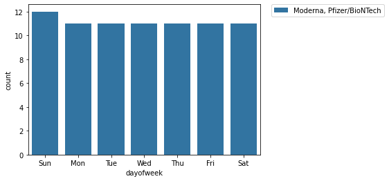

```python
sns.countplot(x = 'dayofweek', data = US, hue = 'vaccines')
plt.legend(bbox_to_anchor = (1.05,1), loc = 2, borderaxespad = 0.)
```

```python
US.iplot(kind = 'bar', x = 'dayofweek', y = 'daily_vaccinations')
```

[interactive chart not shown]

```python
#People vaccinated per population
```

```python
per100 = vaccine.groupby('country')['people_vaccinated_per_hundred', 'people_fully_vaccinated_per_hundred'].sum()
```

```python
per100 = per100.reset_index(level=[0])
```

```python
per100_10 = per100.nlargest(10, 'people_vaccinated_per_hundred')
```

```python
#Plotly
```

```python
daily_10.iplot(kind = 'bar', x = 'country', y = 'daily_vaccinations')
```

[interactive chart not shown]

```python
vaccine[['people_vaccinated', 'people_fully_vaccinated']].iplot(kind = 'spread')
```

[interactive chart not shown]

```python
vaccine['vaccines'].iplot(kind = 'hist')
```

[interactive chart not shown]

```python
US['vaccines'].iplot(kind = 'hist')
```

[interactive chart not shown]

```python
per100_10.iplot(kind = 'bar', x = 'country', y = 'people_vaccinated_per_hundred')
```

[interactive chart not shown]

```python
per100_10.iplot(kind = 'bar', x = 'country', y = 'people_fully_vaccinated_per_hundred')
```

[interactive chart not shown]

```python
#seaborn
```

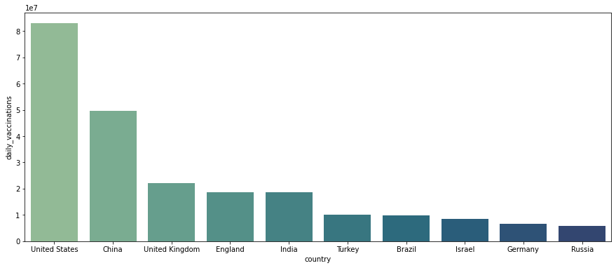

```python
plt.figure(figsize = (15,6))
sns.barplot(x = 'country', y = 'daily_vaccinations', data = daily_10, palette = 'crest')
```

**Conclusion**  
Analyzed same KPIs twice on **February 23** and **March 9**. **28** unique countries are added in two weeks. Following combination of vaccines are most used throughout the world: **Moderna, Oxford/AstraZeneca, Pfizer/BioNTech**. Since US and UK are one of the most leading vaccination countries and they are using Moderna/Pfizer and Oxford/AstraZeneca, respectively, the fact that vaccine type usage is a logical conclusion. Also, Israel still stands its first place on ‘Vaccination_per_hundred’ and as of 03/09/21, Israel reached 5 millionth vaccinations.